# Advanced Analytics Project Report

## Classification Dataset Report

**Introduction**

In this analysis we are exploring the “Car Classification data set, We are implementing multiple machine learning techniques like K Nearest Neighbor (KNN), Decision Tree, Random Forest and XGBoost classification models. The purpose is to evaluate and compare the effectiveness of different models in categorising the vehicles condition. This analysis aims to identify the best predictive model but also to provide actionable insight in automotive classification scenarios.

```
##   Buying.Price Maintainence Doors Persons Lug_Space Safety Class
## 1        vhigh        vhigh     2       2     small    low unacc
## 2        vhigh        vhigh     2       2     small    med unacc
## 3        vhigh        vhigh     2       2     small   high unacc
## 4        vhigh        vhigh     2       2       med    low unacc
## 5        vhigh        vhigh     2       2       med    med unacc
## 6        vhigh        vhigh     2       2       med   high unacc
```

**Data Description and Exploration**

The data set used for this project is Car Classification Dataset, which categories cars into different attributes relevant to customer decision-making. The target variable is Class which is categorised into 4 Classes: unacc (unacceptable), acc (acceptable), good and vgood (very good). The data set includes the following variables:

```
## 'data.frame':    1728 obs. of  7 variables:
##  $ Buying.Price: Factor w/ 4 levels "high","low","med",..: 4 4 4 4 4 4 4 4 4 4 ...
##  $ Maintainence: Factor w/ 4 levels "high","low","med",..: 4 4 4 4 4 4 4 4 4 4 ...
##  $ Doors       : Factor w/ 4 levels "2","3","4","5more": 1 1 1 1 1 1 1 1 1 1 ...
##  $ Persons     : Factor w/ 3 levels "2","4","more": 1 1 1 1 1 1 1 1 1 2 ...
##  $ Lug_Space   : Factor w/ 3 levels "big","med","small": 3 3 3 2 2 2 1 1 1 3 ...
##  $ Safety      : Factor w/ 3 levels "high","low","med": 2 3 1 2 3 1 2 3 1 2 ...
##  $ Class       : Factor w/ 4 levels "acc","good","unacc",..: 3 3 3 3 3 3 3 3 3 3 ...
```

**Data Cleaning and Pre Processing**

- Categorical variables Doors and Persons has values like “5 more” and “more” which are re coded to “5+” to simplify easy interpretation.
- All the variables are categorical which are converted into factors making it perfect for classification.

```
## Buying.Price :  vhigh, high, med, low
## Maintainence :  vhigh, high, med, low
## Doors :  1, 2, 3, 5+
## Persons :  1, 2, 5+
## Lug_Space :  small, med, big
## Safety :  low, med, high
## Class :  unacc, acc, vgood, good
```

- No blanks or missing columns are found in data set upon checking it with “sapply(Car, function(x) sum(x ==”“))”

```
## Buying.Price Maintainence        Doors      Persons    Lug_Space       Safety
##            0            0            0            0            0            0
##        Class
##            0
```

**Visual Exploration**

1. Count Plot for each Feature
- The count plot shows that the target variable Class is imbalanced, with a higher proportion of unacc class.
- All other feature variables are equally distributed and balanced.

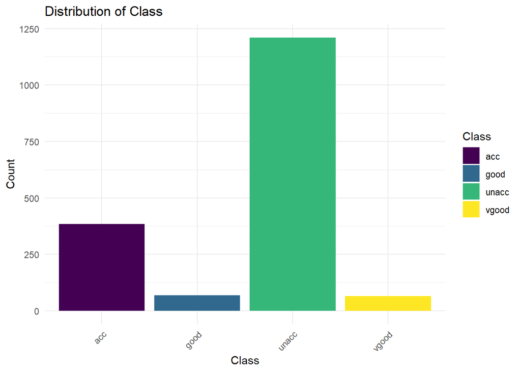

2. Features vs Class Proportion
- This provides insights into how each feature is strongly associated with final classification.

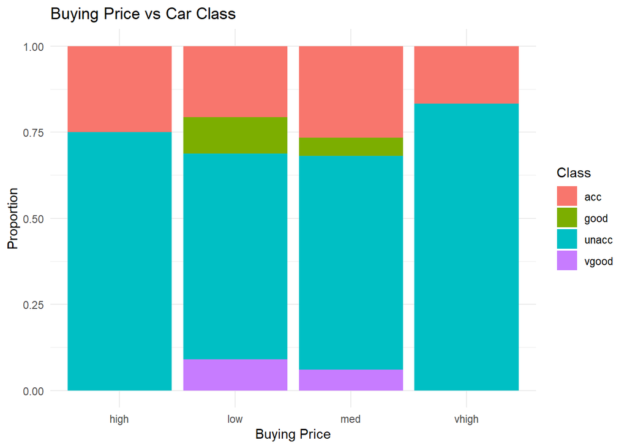

**Data Splitting**

To evaluate the model’s performance and to avoid over fitting, the data set was splitted into training and validation sets.

1. Splitting Method
- The data set containing, 1728 rows were randomly splitted using a 75:25 ratio:
- 75% of records were used for training the model.
- 25% of records were used for validating(testing) purpose.

The summary function was applied to both Training and Validation set to confirm the consistency between the variables. This represents that both sets are representative of the full data set and the model won’t be biased due to skewed distribution.

```r
summary(TrainSet)
```

```
##  Buying.Price Maintainence    Doors             Persons          Lug_Space
##  high :335    high :318    Length:1296        Length:1296        big  :432
##  low  :320    low  :327    Class :character   Class :character   med  :437
##  med  :326    med  :332    Mode  :character   Mode  :character   small:427
##  vhigh:315    vhigh:319
##   Safety      Class
##  high:435   acc  :294
##  low :432   good : 52
##  med :429   unacc:902
##             vgood: 48
```

```r
summary(ValidSet)
```

```
##  Buying.Price Maintainence    Doors             Persons          Lug_Space
##  high : 97    high :114    Length:432         Length:432         big  :144
##  low  :112    low  :105    Class :character   Class :character   med  :139
##  med  :106    med  :100    Mode  :character   Mode  :character   small:149
##  vhigh:117    vhigh:113
##   Safety      Class
##  high:141   acc  : 90
##  low :144   good : 17
##  med :147   unacc:308
##             vgood: 17
```

**Model Building and Evaluation**

**1. Decision Tree**

```
##
##
##    Cell Contents
## |-------------------------|
## |                       N |
## |         N / Table Total |
## |-------------------------|
##
##
## Total Observations in Table:  432
##
##
##                | Predicted Default
## Actual Default |       acc |      good |     unacc |     vgood | Row Total |
## ---------------|-----------|-----------|-----------|-----------|-----------|
##            acc |        82 |         3 |         2 |         3 |        90 |
##                |     0.190 |     0.007 |     0.005 |     0.007 |           |
## ---------------|-----------|-----------|-----------|-----------|-----------|
##           good |         0 |        14 |         0 |         3 |        17 |
##                |     0.000 |     0.032 |     0.000 |     0.007 |           |
## ---------------|-----------|-----------|-----------|-----------|-----------|
##          unacc |         9 |         0 |       299 |         0 |       308 |
##                |     0.021 |     0.000 |     0.692 |     0.000 |           |
## ---------------|-----------|-----------|-----------|-----------|-----------|
##          vgood |         4 |         0 |         0 |        13 |        17 |
##                |     0.009 |     0.000 |     0.000 |     0.030 |           |
## ---------------|-----------|-----------|-----------|-----------|-----------|
##   Column Total |        95 |        17 |       301 |        19 |       432 |
## ---------------|-----------|-----------|-----------|-----------|-----------|
##
##
```

There were noticeable mis-classifications in the acc and good classes. It predicted class as very good for acceptable, suggesting that the decision tree is not capable for handling complex structures or interactions among features.

**2. Random Forest**

```
##
##
##    Cell Contents
## |-------------------------|
## |                       N |
## |         N / Table Total |
## |-------------------------|
##
##
## Total Observations in Table:  432
##
##
##                | Predicted Default
## Actual Default |       acc |      good |     unacc |     vgood | Row Total |
## ---------------|-----------|-----------|-----------|-----------|-----------|
##            acc |        88 |         0 |         0 |         2 |        90 |
##                |     0.204 |     0.000 |     0.000 |     0.005 |           |
## ---------------|-----------|-----------|-----------|-----------|-----------|
##           good |         3 |        11 |         0 |         3 |        17 |
##                |     0.007 |     0.025 |     0.000 |     0.007 |           |
## ---------------|-----------|-----------|-----------|-----------|-----------|
##          unacc |         9 |         0 |       299 |         0 |       308 |
##                |     0.021 |     0.000 |     0.692 |     0.000 |           |
## ---------------|-----------|-----------|-----------|-----------|-----------|
##          vgood |         3 |         0 |         0 |        14 |        17 |
##                |     0.007 |     0.000 |     0.000 |     0.032 |           |
## ---------------|-----------|-----------|-----------|-----------|-----------|
##   Column Total |       103 |        11 |       299 |        19 |       432 |
## ---------------|-----------|-----------|-----------|-----------|-----------|
##
##
```

**3. XGBoost**

- Model Overview: XGBoost builds the trees sequentially, where every tree attempts to correct the mistake made by previous ones. XGBoost is known for its accuracy, speed, and ability to handle complex data.
- Data Preparation: Unlike the other models Decision Tree and Random Forest, XGBoost requires the data to be in numeric matrix format Therefore:
  - All the categorical predictors were one-hot encoded.
  - The target variable was converted into numeric labels starting from 0, as a requirement for multi-class classification.
- Model Training: The model was trained using the xgboost() function with the following parameters:
  - objective = “multi:softmax” for multi-class classification
  - num_class = 4 to represent the 4 target classes
  - nrounds = 100 boosting rounds
  - max_depth = 4 for controlling tree depth
  - eta = 0.3 as the learning rate
- Model Evaluation: Predictions made on the data set were made on the numeric metrics which were converted back into factors for comparison. The XGBoost model has achieved the most accuracy among all the models with total accuracy of **99.54%**. It showed high class precision in identifying all the Classes. The model handled class imbalance and complex feature interactions better then the traditional models.

```
##
##
##    Cell Contents
## |-------------------------|
## |                       N |
## |         N / Table Total |
## |-------------------------|
##
##
## Total Observations in Table:  432
##
##
##                | Predicted Default
## Actual Default |       acc |      good |     unacc |     vgood | Row Total |
## ---------------|-----------|-----------|-----------|-----------|-----------|
##            acc |        89 |         1 |         0 |         0 |        90 |
##                |     0.206 |     0.002 |     0.000 |     0.000 |           |
## ---------------|-----------|-----------|-----------|-----------|-----------|
##           good |         1 |        16 |         0 |         0 |        17 |
##                |     0.002 |     0.037 |     0.000 |     0.000 |           |
## ---------------|-----------|-----------|-----------|-----------|-----------|
##          unacc |         0 |         0 |       308 |         0 |       308 |
##                |     0.000 |     0.000 |     0.713 |     0.000 |           |
## ---------------|-----------|-----------|-----------|-----------|-----------|
##          vgood |         0 |         0 |         0 |        17 |        17 |
##                |     0.000 |     0.000 |     0.000 |     0.039 |           |
## ---------------|-----------|-----------|-----------|-----------|-----------|
##   Column Total |        90 |        17 |       308 |        17 |       432 |
## ---------------|-----------|-----------|-----------|-----------|-----------|
##
##
```

**4. K-Nearest Neighbor(KNN)**

- Model Overview: K-Nearest Neighbors (KNN) is a non-parametric, instance-based learning algorithm that classifies data points based on the majority label of their k closest neighbors in the feature space.
- Data Preparation: The KNN model was trained using the same numerically encoded data preparation for the XGBoost model. Target variable is encoded as numerical labels 0 to 3, representing the four car classes. The data was split into training and valid data using the same indices as other model to maintain the data consistency on training data.
- Model Training and Optimal K Selection: To find the most appropriate number of neighbors(k), a loop was run from 1 to 45. Accuracy was calculated for each k, and the best performing value was selected.

```
## Best k = 2 with Accuracy = 93.98 %
```

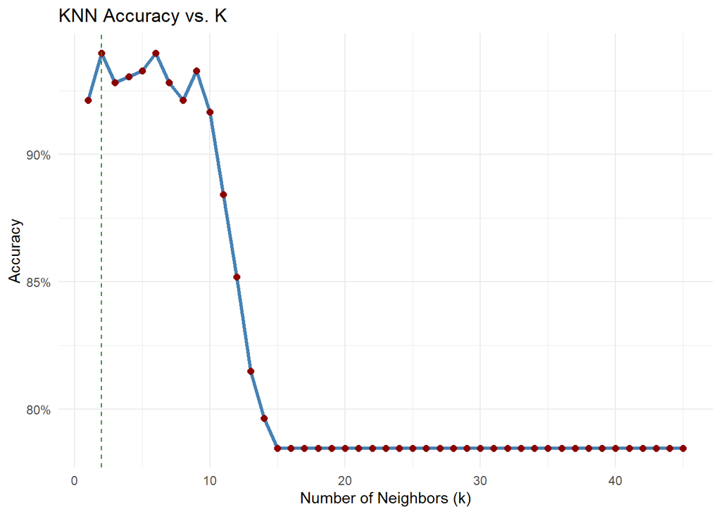

```r
generate_crosstab(ValidSet$Class, knn_pred, "Actual Default", "Predicted Default")
```

[output not shown]

## Multiple Linear Regression Report

**Introduction**

In this study, we are applying regression technique to a data set containing housing information to build a predictive model based on the housing prices on variables such as house age, distance to nearest station, number of convenience stores and geographic co ordinates.

**Dataset Overview**

The dataset contains 414 observations and includes variables related to real estate valuation in Taipan, Taiwan. The target variable is House Price, which was computed by converting the price per unit area to total price in local currency.

```
## # A tibble: 6 × 8
##      No `X1 transaction date` `X2 house age` X3 distance to the nearest MRT st…¹
##   <dbl>                 <dbl>          <dbl>                               <dbl>
## 1     1                 2013.           32                                  84.9
## 2     2                 2013.           19.5                               307.
## 3     3                 2014.           13.3                               562.
## 4     4                 2014.           13.3                               562.
## 5     5                 2013.            5                                 391.
## 6     6                 2013.            7.1                              2175.
## # ℹ abbreviated name: ¹`X3 distance to the nearest MRT station`
## # ℹ 4 more variables: `X4 number of convenience stores` <dbl>,
## #   `X5 latitude` <dbl>, `X6 longitude` <dbl>,
## #   `Y house price of unit area` <dbl>
```

**Data Structure and Summary**

The data has 8 variables, the variables include date, house age, distance to station, number of stores, latitude, longitude, and price per unit area.

```
## tibble [414 × 8] (S3: tbl_df/tbl/data.frame)
##  $ No                                    : num [1:414] 1 2 3 4 5 6 7 8 9 10 ...
##  $ X1 transaction date                   : num [1:414] 2013 2013 2014 2014 2013 ...
##  $ X2 house age                          : num [1:414] 32 19.5 13.3 13.3 5 7.1 34.5 20.3 31.7 17.9 ...
##  $ X3 distance to the nearest MRT station: num [1:414] 84.9 306.6 562 562 390.6 ...
##  $ X4 number of convenience stores       : num [1:414] 10 9 5 5 5 3 7 6 1 3 ...
##  $ X5 latitude                           : num [1:414] 25 25 25 25 25 ...
##  $ X6 longitude                          : num [1:414] 122 122 122 122 122 ...
##  $ Y house price of unit area            : num [1:414] 37.9 42.2 47.3 54.8 43.1 32.1 40.3 46.7 18.8 22.1 ...
```

**Data Cleaning and Preprocessing**

- Checking for any blank variables in the dataset.

```
##                                     No                    X1 transaction date
##                                      0                                      0
##                           X2 house age X3 distance to the nearest MRT station
##                                      0                                      0
##        X4 number of convenience stores                            X5 latitude
##                                      0                                      0
##                           X6 longitude             Y house price of unit area
##                                      0                                      0
```

- Dates were converted into decimal format to year-month. Unwanted variables like Row_No, Date, and original price were removed after transformation. House prices were calculated as per the Taiwan price system (unit_price * 1000) / 3.3. Outliers outside the range 3,000 to 25000 were removed from the dataset.

```
## [1] "Row_No"           "Date"             "House_Age"        "Dist_to_station"
## [5] "No_of_stores"     "Latitude"         "Longitude"        "House_price_unit"
```

```
## tibble [412 × 9] (S3: tbl_df/tbl/data.frame)
##  $ Row_No          : num [1:412] 1 2 3 4 5 6 7 8 9 10 ...
##  $ Date            : chr [1:412] "2012-12" "2012-12" "2013-07" "2013-07" ...
##  $ House_Age       : num [1:412] 32 19.5 13.3 13.3 5 7.1 34.5 20.3 31.7 17.9 ...
##  $ Dist_to_station : num [1:412] 84.9 306.6 562 562 390.6 ...
##  $ No_of_stores    : num [1:412] 10 9 5 5 5 3 7 6 1 3 ...
##  $ Latitude        : num [1:412] 25 25 25 25 25 ...
##  $ Longitude       : num [1:412] 122 122 122 122 122 ...
##  $ House_price_unit: num [1:412] 37.9 42.2 47.3 54.8 43.1 32.1 40.3 46.7 18.8 22.1 ...
##  $ House_Price     : num [1:412] 11485 12788 14333 16606 13061 ...
```

**Exploratory Data Analysis**

- Histogram and Boxplot to detect the outliers.

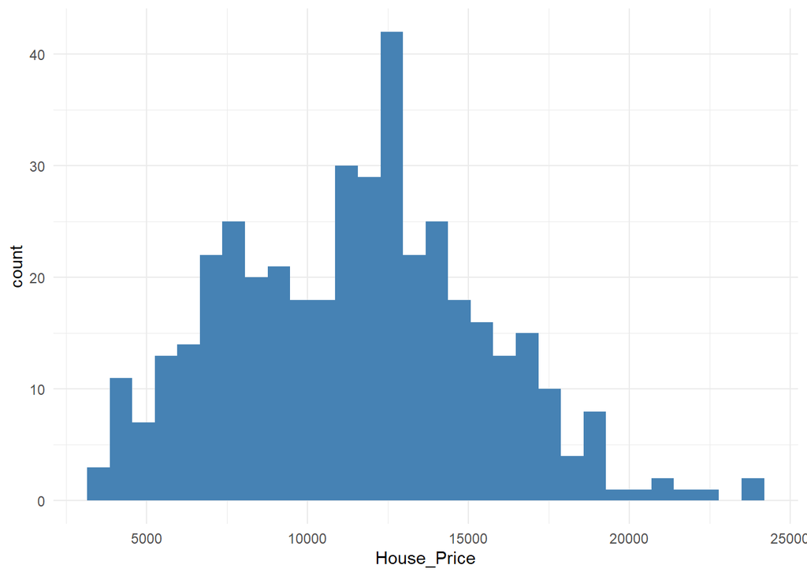

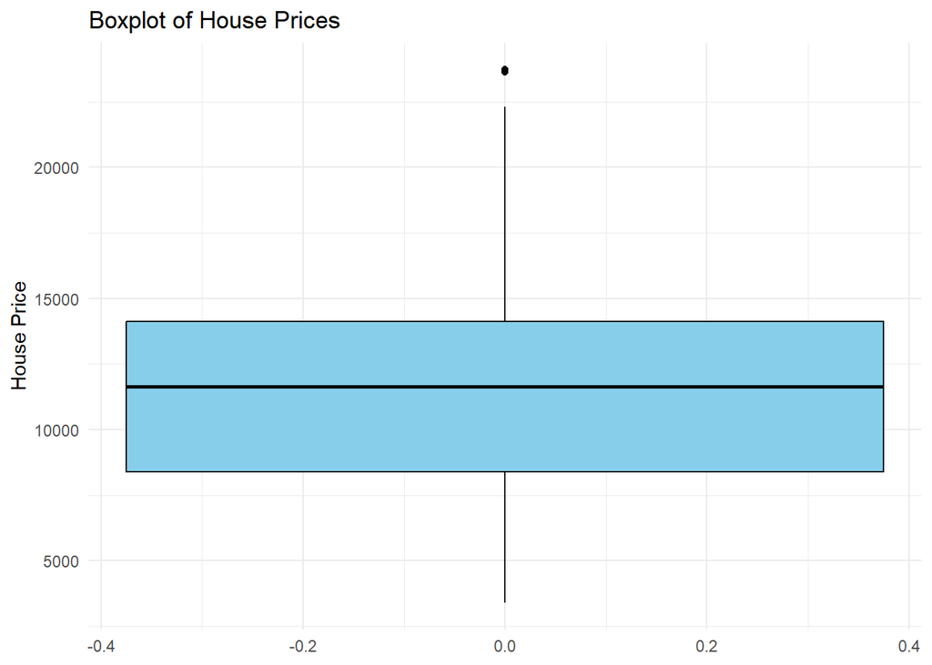

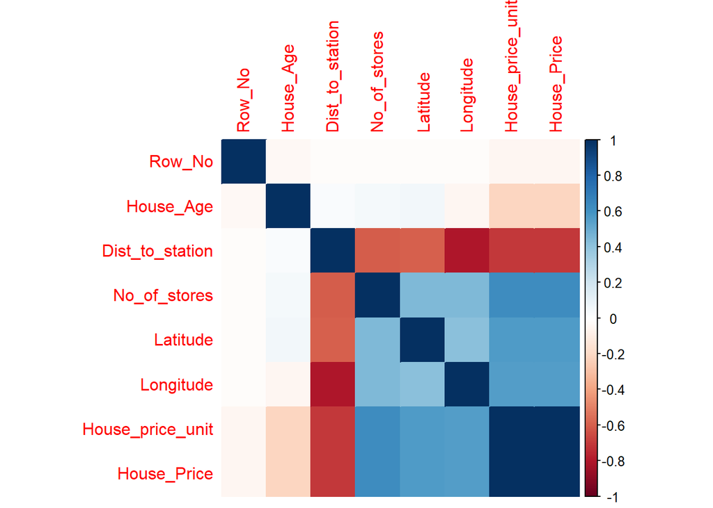

```
##                   House_Age Dist_to_station No_of_stores   Latitude   Longitude
## House_Age        1.00000000      0.02434407   0.04856282  0.0547792 -0.04863861
## Dist_to_station  0.02434407      1.00000000  -0.60499512 -0.5920535 -0.80705554
## No_of_stores     0.04856282     -0.60499512   1.00000000  0.4473292  0.44903273
## Latitude         0.05477920     -0.59205346   0.44732918  1.0000000  0.41391271
## Longitude       -0.04863861     -0.80705554   0.44903273  0.4139127  1.00000000
## House_Price     -0.21384600     -0.70193889   0.62063149  0.5645720  0.55467991
##                 House_Price
## House_Age        -0.2138460
## Dist_to_station  -0.7019389
## No_of_stores      0.6206315
## Latitude          0.5645720
## Longitude         0.5546799
## House_Price       1.0000000
```

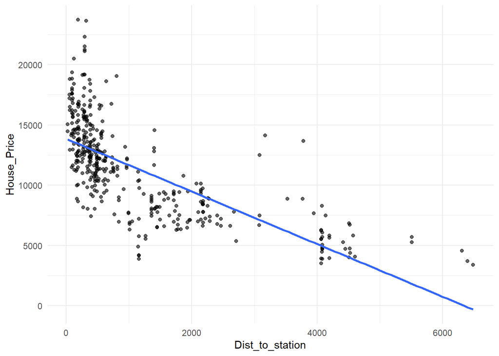

- A pairs plot was used to examine multivariate relationships visually.

[figure not shown]

[output not shown]

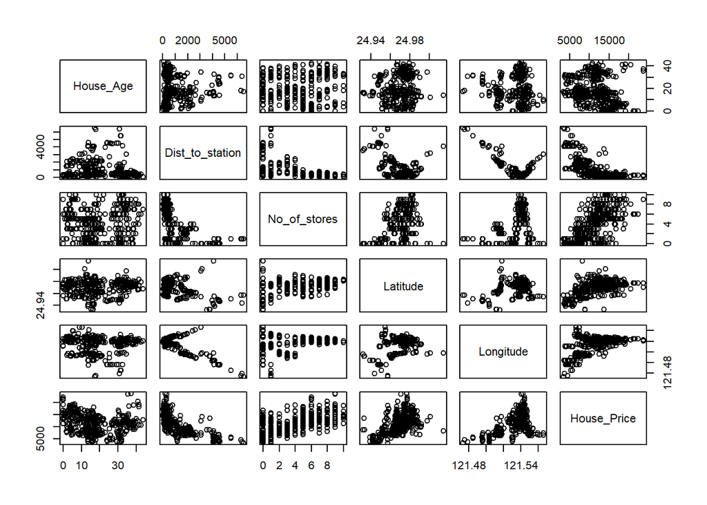

**Data Splitting**

[figure not shown]

**Model Building and Evaluation**

**1. Basic Linear Model**: The model assumes linear relationship between the independent variables like house age, distance to nearest station, number of stores, etc and the dependent variable is House Price.

```
##
## Call:
## lm(formula = House_Price ~ ., data = train)
##
## Residuals:
##     Min      1Q  Median      3Q     Max
## -5366.2 -1432.2  -398.7  1342.7  9310.7
##
## Coefficients:
##                   Estimate Std. Error t value Pr(>|t|)
## (Intercept)     -1.778e+06  1.722e+06  -1.032    0.303
## House_Age       -8.771e+01  1.095e+01  -8.011 2.47e-14 ***
## Dist_to_station -1.276e+00  2.028e-01  -6.289 1.12e-09 ***
## No_of_stores     3.221e+02  5.353e+01   6.018 5.10e-09 ***
## Latitude         6.204e+04  1.337e+04   4.641 5.16e-06 ***
## Longitude        1.992e+03  1.351e+04   0.147    0.883
## ---
## Signif. codes:  0 '***' 0.001 '**' 0.01 '*' 0.05 '.' 0.1 ' ' 1
##
## Residual standard error: 2192 on 303 degrees of freedom
## Multiple R-squared:  0.6409, Adjusted R-squared:  0.635
## F-statistic: 108.2 on 5 and 303 DF,  p-value: < 2.2e-16
```

- Model Observation and summary output: There is approximately 64% of the variance in house prices is explained by this model. Dist_to_station had a strong negative correlation with the house price, meaning prices tend to drop the farther the property is from the station. House Age also have a negative correlation, suggesting older houses tend to be slightly cheaper.

**2. Improved Linear Regression Model**

- Feature Engineering
  - House_Age: Squared the age of house variable to model potential non-linear aging effects.
  - Dist_to_station: Squaring the Dist_to_station showed an accelerating impact on the models R-squared and mean absolute error.
  - Number_of_stores: A binary feature created to distinguish properties with 5 or more stores around them, which may increase the valuation.

```r
#Improving the performance of Model
Valuation_Cleared$House_Age2 <- Valuation_Cleared$House_Age^2
Valuation_Cleared$Dist_to_station2 <- Valuation_Cleared$Dist_to_station^2
Valuation_Cleared$Store_gt_5 <- ifelse(Valuation_Cleared$No_of_stores >= 5, 1, 0)

#Creating new test and train set for the updated model
train_improved <- Valuation_Cleared[trainIndex,]
test_improved <- Valuation_Cleared[-trainIndex,]

str(train_improved)
```

```
## tibble [309 × 9] (S3: tbl_df/tbl/data.frame)
##  $ House_Age       : num [1:309] 14 20.4 15.2 10.3 25.3 2.5 31 4.8 8.1 21.7 ...
##  $ Dist_to_station : num [1:309] 439 2470 461 3080 1584 ...
##  $ No_of_stores    : num [1:309] 1 4 5 0 3 4 0 3 5 0 ...
##  $ Latitude        : num [1:309] 25 25 25 25 25 ...
##  $ Longitude       : num [1:309] 122 122 122 122 122 ...
##  $ House_Price     : num [1:309] 12909 7212 10485 7485 9273 ...
##  $ House_Age2      : num [1:309] 196 416 231 106 640 ...
##  $ Dist_to_station2: num [1:309] 192590 6099146 212615 9485722 2508175 ...
##  $ Store_gt_5      : num [1:309] 0 0 1 0 0 0 0 0 1 0 ...
```

```
##
## Call:
## lm(formula = House_Price ~ ., data = train_improved)
##
## Residuals:
##     Min      1Q  Median      3Q     Max
## -4680.9 -1181.0   -78.4  1007.7  9736.2
##
## Coefficients:
##                    Estimate Std. Error t value Pr(>|t|)
## (Intercept)      -2.735e+06  1.566e+06  -1.746   0.0818 .
## House_Age        -2.561e+02  3.845e+01  -6.660 1.30e-10 ***
## Dist_to_station  -2.802e+00  3.670e-01  -7.633 3.08e-13 ***
## No_of_stores      9.502e+01  8.205e+01   1.158   0.2477
## Latitude          6.968e+04  1.223e+04   5.700 2.87e-08 ***
## Longitude         8.314e+03  1.242e+04   0.669   0.5038
## House_Age2        4.255e+00  9.418e-01   4.518 9.00e-06 ***
## Dist_to_station2  3.494e-04  6.215e-05   5.622 4.32e-08 ***
## Store_gt_5        6.962e+02  5.065e+02   1.375   0.1703
## ---
## Signif. codes:  0 '***' 0.001 '**' 0.01 '*' 0.05 '.' 0.1 ' ' 1
##
## Residual standard error: 1950 on 300 degrees of freedom
## Multiple R-squared:  0.7186, Adjusted R-squared:  0.7111
## F-statistic: 95.79 on 8 and 300 DF,  p-value: < 2.2e-16
```

**Model Evaluation Metrics**

The improved regression model increased R² from 0.58 to 0.66 while reducing RMSE and MAE, confirming that feature engineering significantly enhanced model accuracy and predictive reliability.

```
##                    R2     RMSE     MAE
## Original_Model 0.5808 3023.419 2144.46
## Improved_Model 0.6551 2742.314 1872.46
```

**Conclusion** In conclusion, XGBoost was the top performer for classification, while the improved linear regression model was the best for regression. Feature engineering emerged as a key factor in enhancing model performance across both contexts.